# Practical Machine Learning Final Project

Author: Felix Ling, Date: September 3, 2016

The main issue in creating a machine learning model from the exercise data was that there were a very large number of variables. With all of the variables included, building the more complex models like random forest took prohibitively long, sometimes produced warnings (e.g., “variable ‘kurtosis_roll_belt’ is not a factor”), and often produced models that were unable to make any predictions due to variables unavailable in the test set.

Thus, it was necessary to narrow down the number of variables to something more manageable.

# Subsetting

Upon inspection, there were a number of variables that only assumed one of two possible values: blank and “div/0” (an undefined value resulting in a division by 0). These were:

```r
kurtosis_yaw_belt, skewness_yaw_belt, kurtosis_yaw_dumbbell, skewness_yaw_dumbbell,
amplitude_yaw_dumbbell, kurtosis_yaw_forearm, skewness_yaw_forearm, amplitude_yaw_forearm
```

Likewise, the following variables could only be blank, “div/0,” or a handful of other values:

```r
amplitude_yaw_belt, kurtosis_roll_arm, skewness_roll_arm, kurtosis_picth_arm, skewness_pitch_arm,
kurtosis_yaw_arm, skewness_yaw_arm, kurtosis_roll_dumbbell, skewness_roll_dumbbell,
kurtosis_picth_dumbbell, skewness_pitch_dumbbell, kurtosis_roll_belt, kurtosis_roll_forearm,
skewness_roll_forearm, kurtosis_picth_forearm, skewness_pitch_forearm
```

It isn’t that surprising that these variables were not that useful because they simply describe the distribution of other variables. For example, kurtosis_yaw_dumbbell describes the thickness of the tails of the distribution of yaw_dumbbell.

Next, viewing the summary of the remaining variables shows that quite a few variables are mostly made up of NAs, meaning that the observation was not available. To keep this report concise, this command only shows the first 12.

```r
summary (PmlSub[1:12])
```

```
##    roll_belt        pitch_belt          yaw_belt       total_accel_belt
##  Min.   :-28.90   Min.   :-55.8000   Min.   :-180.00   Min.   : 0.00
##  1st Qu.:  1.10   1st Qu.:  1.7600   1st Qu.: -88.30   1st Qu.: 3.00
##  Median :113.00   Median :  5.2800   Median : -13.00   Median :17.00
##  Mean   : 64.41   Mean   :  0.3053   Mean   : -11.21   Mean   :11.31
##  3rd Qu.:123.00   3rd Qu.: 14.9000   3rd Qu.:  12.90   3rd Qu.:18.00
##  Max.   :162.00   Max.   : 60.3000   Max.   : 179.00   Max.   :29.00
##
##  max_roll_belt     max_picth_belt   max_yaw_belt   min_roll_belt
##  Min.   :-94.300   Min.   : 3.00          :19216   Min.   :-180.00
##  1st Qu.:-88.000   1st Qu.: 5.00   -1.1   :   30   1st Qu.: -88.40
##  Median : -5.100   Median :18.00   -1.4   :   29   Median :  -7.85
##  Mean   : -6.667   Mean   :12.92   -1.2   :   26   Mean   : -10.44
##  3rd Qu.: 18.500   3rd Qu.:19.00   -0.9   :   24   3rd Qu.:   9.05
##  Max.   :180.000   Max.   :30.00   -1.3   :   22   Max.   : 173.00
##  NA's   :19216     NA's   :19216   (Other):  275   NA's   :19216
##  min_pitch_belt   min_yaw_belt   amplitude_roll_belt amplitude_pitch_belt
##  Min.   : 0.00          :19216   Min.   :  0.000     Min.   : 0.000
##  1st Qu.: 3.00   -1.1   :   30   1st Qu.:  0.300     1st Qu.: 1.000
##  Median :16.00   -1.4   :   29   Median :  1.000     Median : 1.000
##  Mean   :10.76   -1.2   :   26   Mean   :  3.769     Mean   : 2.167
##  3rd Qu.:17.00   -0.9   :   24   3rd Qu.:  2.083     3rd Qu.: 2.000
##  Max.   :23.00   -1.3   :   22   Max.   :360.000     Max.   :12.000
##  NA's   :19216   (Other):  275   NA's   :19216       NA's   :19216
```

Refer to the summaries of max_roll_belt, max_pictch_belt, min_roll_belt, to see some examples that were mostly NA’s.

Overall, the following variables had 19216 NA’s out of a total of 19622 observations, meaning that most of the data was not available:

```r
max_roll_belt, max_picth_belt, min_roll_belt, min_pitch_belt, amplitude_pitch_belt,
var_total_accel_belt, avg_roll_belt, stddev_roll_belt, var_roll_belt, avg_pitch_belt,
stddev_pitch_belt, var_pitch_belt, avg_yaw_belt, var_accel_arm, avg_roll_arm, stddev_roll_arm,
var_roll_arm, avg_pitch_arm, stddev_pitch_arm, var_pitch_arm, avg_yaw_arm, stddev_yaw_arm,
var_yaw_arm, max_roll_arm, max_picth_arm, max_yaw_arm, min_roll_arm, min_pitch_arm, min_yaw_arm,
amplitude_roll_arm, amplitude_pitch_arm, amplitude_yaw_arm, max_roll_dumbbell,
max_picth_dumbbell, min_roll_dumbbell, min_pitch_dumbbell, amplitude_roll_dumbbell,
amplitude_pitch_dumbbell, var_accel_dumbbell, avg_roll_dumbbell, stddev_roll_dumbbell,
var_roll_dumbbell, avg_pitch_dumbbell, stddev_pitch_dumbbell, var_pitch_dumbbell,
avg_yaw_dumbbell, stddev_yaw_dumbbell, var_yaw_dumbbell, max_roll_forearm, max_picth_forearm,
min_roll_forearm, min_pitch_forearm, amplitude_roll_forearm, amplitude_pitch_forearm,
var_accel_forearm, avg_roll_forearm, stddev_roll_forearm, var_roll_forearm, avg_pitch_forearm,
stddev_pitch_forearm, var_pitch_forearm, avg_yaw_forearm, stddev_yaw_forearm, var_yaw_forearm
```

Upon the remaining variables, it was helpful to perform some exploratory data analysis using a melt chart, basically density curves (or smoothed histograms) of all the variables in a single chart. The process is detailed here: https://www.r-bloggers.com/how-to-use-data-analysis-for-machine-learning-example-part-1/.

The melt chart looked something like this (for readability, this is only subset of the variables):

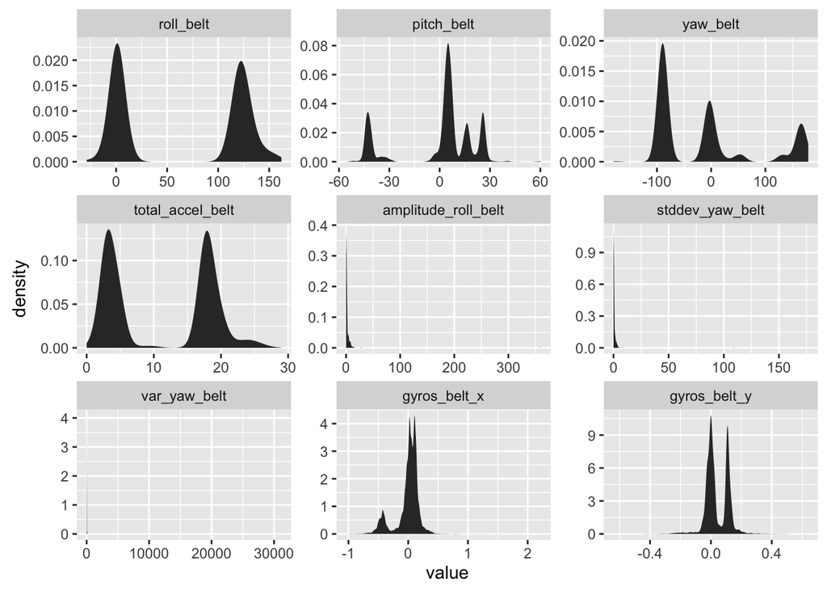

```r
Melt.PmlSub <- melt (PmlSub[1:12])
ggplot (data = Melt.PmlSub, aes (x=value)) + stat_density() + facet_wrap (~variable, scales = "free")
```

It is apparent from this chart that there isn’t very much information emboded in amplitude_roll_belt, stddev_yaw_belt, or var_yaw_belt. Much like the skewness and kurtosis variables, these are again descriptive of the distributions of other variables.

From the full melt chart, the following variables looked the least promising and were also removed:

```r
amplitude_yaw_belt, var_yaw_belt, max_yaw_belt, min_yaw_belt, amplitude_roll_belt,
amplitude_yaw_belt, stddev_yaw_belt, var_yaw_belt, max_yaw_dumbbell, min_yaw_dumbbell,
amplitude_yaw_dumbbell, gyros_dumbbell_x, max_yaw_forearm, min_yaw_forearm,
amplitude_yaw_forearm, gyros_forearm_y, gyros_forearm_z
```

# Training

After that, it was possible to train the random forest model on the remaining 48 variables. I selected random forest because it is one of the top-performing models and was also the model used in [the original study](http://groupware.les.inf.puc-rio.br/public/papers/2013.Velloso.QAR-WLE.pdf). Also, the other models I tried, such as linear discriminant analysis, did not perform very well, with accuracies below 70%.

This is the code used to subset and train the random forest model.

```r
library ("labeling")
library ("digest")
library ("ggplot2")
library ("e1071")
library ("caret")
library ("randomForest")

Pml <- read.csv ("data/pml-training.csv");
PmlTest <- read.csv ("data/pml-testing.csv");

set.seed (2112)

# X is the index of the data!
# Strip out X, user_name, 3 timestamps, 2 window vars.
PmlSub <- Pml[8:dim(Pml)[2]]

# Filter out skewness and kurtosis and other useless variables.
PmlSub <- PmlSub[,-grep("kurt", colnames (PmlSub))]
PmlSub <- PmlSub[,-grep("skew", colnames (PmlSub))]

# Remove the ones with 19612 NAs.
PmlSub <- subset( PmlSub,
                  select = -c(max_roll_belt, max_picth_belt, min_roll_belt, min_pitch_belt,
                              amplitude_pitch_belt, var_total_accel_belt, avg_roll_belt,
                              stddev_roll_belt, var_roll_belt, avg_pitch_belt,
                              stddev_pitch_belt, var_pitch_belt, avg_yaw_belt, var_accel_arm,
                              avg_roll_arm, stddev_roll_arm, var_roll_arm, avg_pitch_arm,
                              stddev_pitch_arm, var_pitch_arm, avg_yaw_arm, stddev_yaw_arm,
                              var_yaw_arm, max_roll_arm, max_picth_arm, max_yaw_arm,
                              min_roll_arm, min_pitch_arm, min_yaw_arm, amplitude_roll_arm,
                              amplitude_pitch_arm, amplitude_yaw_arm, max_roll_dumbbell,
                              max_picth_dumbbell, min_roll_dumbbell, min_pitch_dumbbell,
                              amplitude_roll_dumbbell, amplitude_pitch_dumbbell,
                              var_accel_dumbbell, avg_roll_dumbbell, stddev_roll_dumbbell,
                              var_roll_dumbbell, avg_pitch_dumbbell, stddev_pitch_dumbbell,
                              var_pitch_dumbbell, avg_yaw_dumbbell, stddev_yaw_dumbbell,
                              var_yaw_dumbbell, max_roll_forearm, max_picth_forearm,
                              min_roll_forearm, min_pitch_forearm, amplitude_roll_forearm,
                              amplitude_pitch_forearm, var_accel_forearm, avg_roll_forearm,
                              stddev_roll_forearm, var_roll_forearm, avg_pitch_forearm,
                              stddev_pitch_forearm, var_pitch_forearm, avg_yaw_forearm,
                              stddev_yaw_forearm, var_yaw_forearm) )

# Remove the ones that don't look promising from the melt plot.
PmlSub <- subset( PmlSub,
                  select = -c(amplitude_yaw_belt, var_yaw_belt, max_yaw_belt, min_yaw_belt,
                              amplitude_roll_belt, amplitude_yaw_belt, stddev_yaw_belt,
                              var_yaw_belt, max_yaw_dumbbell, min_yaw_dumbbell,
                              amplitude_yaw_dumbbell, gyros_dumbbell_x, max_yaw_forearm,
                              min_yaw_forearm, amplitude_yaw_forearm, gyros_forearm_y,
                              gyros_forearm_z) )

# NOTE! The same subsetting was performed with PmlTest, but for the sake of concision, the
# code is not shown here.

# Create the training and test sets.
# The test set doesn't have classe, so need to make our own test set.
InTrain = createDataPartition (PmlSub$classe, p = .8)[[1]]
Training = PmlSub[ InTrain, ]
Test = PmlSub[ -InTrain, ]

# Train the Random Forest model.
ModFitRf <- train (classe ~., method = "rf", data = Training)

# Get the model's predictions.
PredRf <- predict (ModFitRf, Test)
```

# Evaluating the model

This is the confusion matrix showing the test set accuracy of the random forest model to be 98.8%, so I expect an out-of-sample error of 1.2%. Due to this high accuracy rate, no cross-validation was performed.

```r
confusionMatrix (Test$classe, PredRf)
```

```
## Confusion Matrix and Statistics
##
##           Reference
## Prediction    A    B    C    D    E
##          A 1115    1    0    0    0
##          B    9  739    9    0    2
##          C    0    7  674    3    0
##          D    0    0   11  631    1
##          E    0    1    2    1  717
##
## Overall Statistics
##
##                Accuracy : 0.988
##                  95% CI : (0.9841, 0.9912)
##     No Information Rate : 0.2865
##     P-Value [Acc > NIR] : < 2.2e-16
##
##                   Kappa : 0.9848
##  Mcnemar's Test P-Value : NA
##
## Statistics by Class:
##
##                      Class: A Class: B Class: C Class: D Class: E
## Sensitivity            0.9920   0.9880   0.9684   0.9937   0.9958
## Specificity            0.9996   0.9937   0.9969   0.9964   0.9988
## Pos Pred Value         0.9991   0.9736   0.9854   0.9813   0.9945
## Neg Pred Value         0.9968   0.9972   0.9932   0.9988   0.9991
## Prevalence             0.2865   0.1907   0.1774   0.1619   0.1835
## Detection Rate         0.2842   0.1884   0.1718   0.1608   0.1828
## Detection Prevalence   0.2845   0.1935   0.1744   0.1639   0.1838
## Balanced Accuracy      0.9958   0.9908   0.9826   0.9950   0.9973
```

These are the most important variables to this model.

```r
varImp (ModFitRf)
```

```
## rf variable importance
##
##   only 20 most important variables shown (out of 47)
##
##                      Overall
## yaw_belt              100.00
## pitch_forearm          78.74
## magnet_dumbbell_z      68.76
## magnet_dumbbell_y      51.75
## roll_forearm           44.79
## accel_belt_z           36.49
## gyros_belt_z           27.31
## magnet_belt_z          26.79
## accel_dumbbell_y       26.06
## roll_dumbbell          25.69
## magnet_belt_y          24.77
## magnet_dumbbell_x      23.84
## accel_forearm_x        18.92
## roll_arm               18.74
## total_accel_dumbbell   18.63
## accel_dumbbell_z       18.52
## magnet_belt_x          16.86
## magnet_forearm_z       16.32
## yaw_arm                14.89
## accel_forearm_z        13.02
```

To get a sense of why certain variables were important, see this plot of the two most important variables against classe:

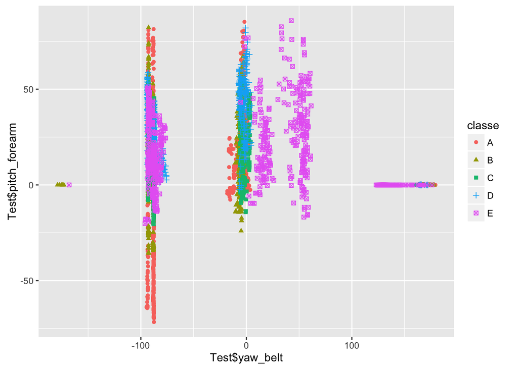

```r
qplot (Test$yaw_belt, Test$pitch_forearm, colour = classe, shape = classe, data = Test)
```

Lastly, this is a plot of the next two most important variables against classe:

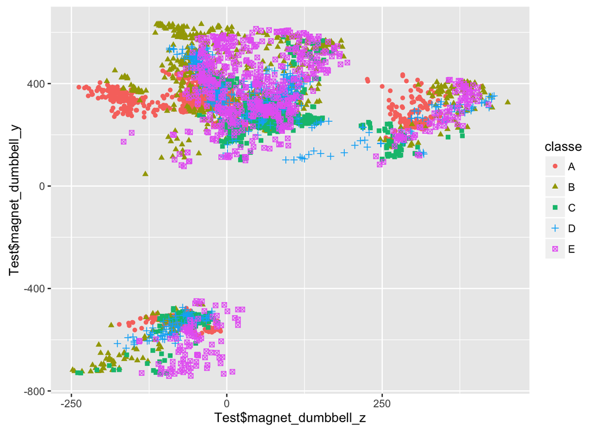

```r
qplot (Test$magnet_dumbbell_z, Test$magnet_dumbbell_y, colour = classe, shape = classe, data = Test)
```